# Seaborn

## Seaborn Tutorial

### Distribution plots

- distplot
- joinplot
- pairplot

Practise problem on IRIS Dataset

```python
import seaborn as sns
```

```python
df=sns.load_dataset("tips")
```

```python
df.head()
```

|  | total_bill | tip | sex | smoker | day | time | size |
| --- | --- | --- | --- | --- | --- | --- | --- |
| 0 | 16.99 | 1.01 | Female | No | Sun | Dinner | 2 |
| 1 | 10.34 | 1.66 | Male | No | Sun | Dinner | 3 |
| 2 | 21.01 | 3.50 | Male | No | Sun | Dinner | 3 |
| 3 | 23.68 | 3.31 | Male | No | Sun | Dinner | 2 |
| 4 | 24.59 | 3.61 | Female | No | Sun | Dinner | 4 |

### Correlation with Heatmap

A correlation heatmap uses colored cells, typically in a monochromatic scale, to show a 2D correlation matrix (table) between two discrete dimensions or event types. It is very important in Feature Selection

```python
df.corr()
```

|  | total_bill | tip | size |
| --- | --- | --- | --- |
| total_bill | 1.000000 | 0.675734 | 0.598315 |
| tip | 0.675734 | 1.000000 | 0.489299 |
| size | 0.598315 | 0.489299 | 1.000000 |

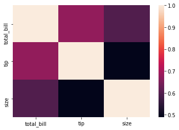

```python
sns.heatmap(df.corr())
```

## JoinPlot

A join plot allows to study the relationship between 2 numeric variables. The central chart display their correlation. It is usually a scatterplot, a hexbin plot, a 2D histogram or a 2D density plot

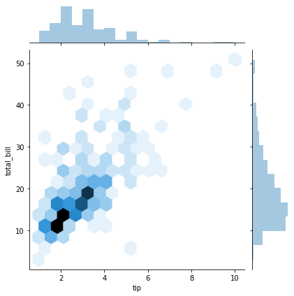

```python
sns.jointplot(x='tip',y='total_bill',data=df,kind='hex')
```

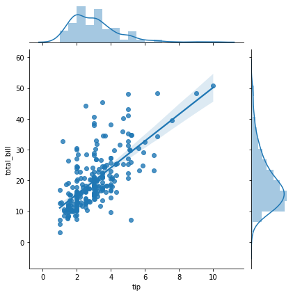

```python
sns.jointplot(x='tip',y='total_bill',data=df,kind='reg')
```

## Pair plot

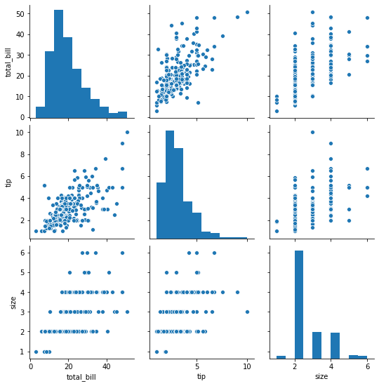

```python
sns.pairplot(df)
```

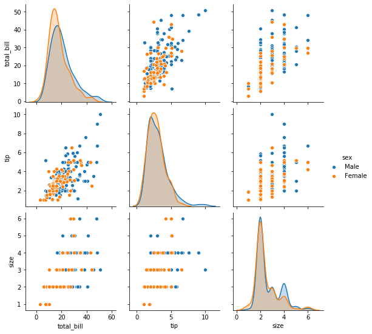

```python
sns.pairplot(df,hue='sex')
```

## Dist plot

Dist plot helps us to check the distribution of the columns feature

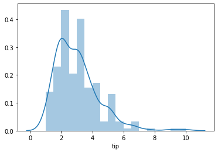

```python
sns.distplot(df['tip'])
```

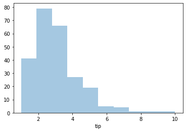

```python
sns.distplot(df['tip'],kde=False,bins=10)
```

## Categorical Plots

Seaborn also helps us in doing the analysis on Categorical Data points. In this section we will discuss about

- boxplot
- violinplot
- countplot
- bar plot

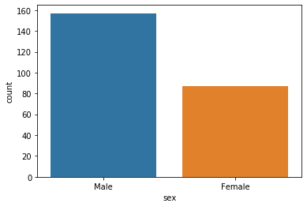

```python
## Count plot

sns.countplot('sex',data=df)
```

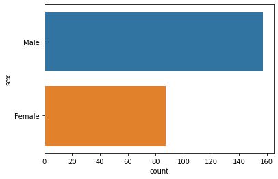

```python
## Count plot

sns.countplot(y='sex',data=df)
```

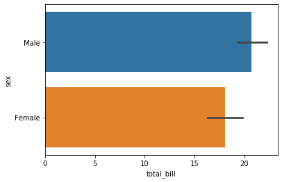

```python
## Bar plot

sns.barplot(x='total_bill',y='sex',data=df)
```

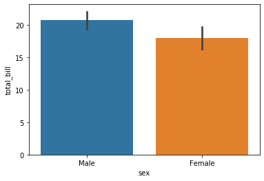

```python
## Bar plot

sns.barplot(x='sex',y='total_bill',data=df)
```

```python
df.head()
```

|  | total_bill | tip | sex | smoker | day | time | size |
| --- | --- | --- | --- | --- | --- | --- | --- |
| 0 | 16.99 | 1.01 | Female | No | Sun | Dinner | 2 |
| 1 | 10.34 | 1.66 | Male | No | Sun | Dinner | 3 |
| 2 | 21.01 | 3.50 | Male | No | Sun | Dinner | 3 |
| 3 | 23.68 | 3.31 | Male | No | Sun | Dinner | 2 |
| 4 | 24.59 | 3.61 | Female | No | Sun | Dinner | 4 |

## Box plot

A box and whisker plot (sometimes called a boxplot) is a graph that presents information from a five-number summary.

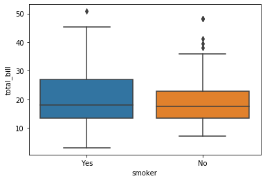

```python
sns.boxplot('smoker','total_bill', data=df)
```

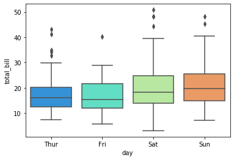

```python
sns.boxplot(x="day", y="total_bill", data=df,palette='rainbow')
```

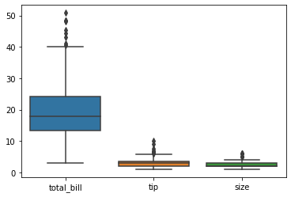

```python
sns.boxplot(data=df,orient='v')
```

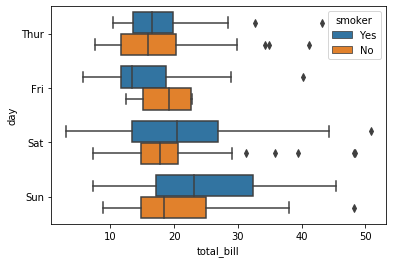

```python
# categorize my data based on some other categories

sns.boxplot(x="total_bill", y="day", hue="smoker",data=df)
```

## Violin Plot

Violin plot helps us to see both the distribution of data in terms of Kernel density estimation and the box plot

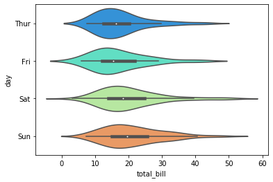

```python
sns.violinplot(x="total_bill", y="day", data=df,palette='rainbow')
```

```python
## Practise Homework

iris = sns.load_dataset('iris')
```

```python
iris.head()
```

|  | sepal_length | sepal_width | petal_length | petal_width | species |
| --- | --- | --- | --- | --- | --- |
| 0 | 5.1 | 3.5 | 1.4 | 0.2 | setosa |
| 1 | 4.9 | 3.0 | 1.4 | 0.2 | setosa |
| 2 | 4.7 | 3.2 | 1.3 | 0.2 | setosa |
| 3 | 4.6 | 3.1 | 1.5 | 0.2 | setosa |
| 4 | 5.0 | 3.6 | 1.4 | 0.2 | setosa |